# Grauwertkookkurenzmatrizen (GLCM)

Beispielhafte Anaylse nach dem Tutorial von Mryka Hall-Beyer.

```python
import numpy as np
import matplotlib.pyplot as plt
import pandas as pd
%matplotlib inline
```

Wir definieren uns zunächst ein Beispielbild mit 4 Graustufen.

```python
image = np.array([[0,0,1,1],[0,0,1,1],[0,2,2,2],[2,2,3,3]])
print(image)
```

```
[[0 0 1 1]
 [0 0 1 1]
 [0 2 2 2]
 [2 2 3 3]]
```

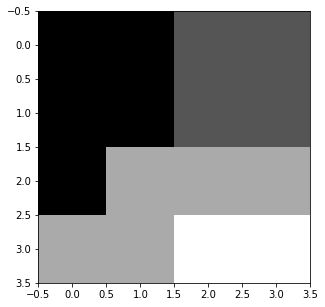

```python
fig,ax = plt.subplots(1,1,figsize=(5,5))
ax.imshow(image,vmin=0,vmax=3,cmap='gray')
```

## GLCM

Dann ermitteln wir die horizontale und vertikale GLCM für eine Nachbarschaft von einem Pixel. Das könnten wir in sechs Richtungen machen:

1. nach links (1,0)
2. nach rechts (-1,0)
3. nach oben (0,-1)
4. nach unten (0,1)
5. diagonal von links unten nach rechts oben (1,-1)
6. diagonal von rechts oben nach links unten (1,1)

und mit Vielfachen davon.

Hier betrachten wir nur die horizontalen und vertikalen Richtungen.

Die GLCM werden gebildet indem man immer den Wert des Nachbarn im gewählten Abstand zum betrachteten Pixel mit dem Pixelwert vergleicht und dann zählt wie häufig die Kombinationen vorkommen.

Für das Beispiel sieht das wie folgt aus.

### Horizontale GLCM

```python
i = np.array([[0],[1],[2],[3]])
j = np.array([0,1,2,3])
```

```python
links = np.array([[2,2,1,0],[0,2,0,0],[0,0,3,1],[0,0,0,1]])
links_df = pd.DataFrame(data=links,
                        columns=j,
                        index=j)
```

```python
links
```

```
array([[2, 2, 1, 0],
       [0, 2, 0, 0],
       [0, 0, 3, 1],
       [0, 0, 0, 1]])
```

```python
links_df
```

|  | 0 | 1 | 2 | 3 |
| --- | --- | --- | --- | --- |
| 0 | 2 | 2 | 1 | 0 |
| 1 | 0 | 2 | 0 | 0 |
| 2 | 0 | 0 | 3 | 1 |
| 3 | 0 | 0 | 0 | 1 |

Diese Matrix ist nicht symmetrisch. Wenn wir sie transponieren erhalten wir die GLCM nach rechts. Wenn wir die linke und rechte GLCM addieren erhalten wir die horizontale GLCM.

```python
rechts = np.transpose(links)
rechts_df = pd.DataFrame(data=rechts,
                         columns=j,
                         index=j)
```

```python
rechts_df
```

|  | 0 | 1 | 2 | 3 |
| --- | --- | --- | --- | --- |
| 0 | 2 | 0 | 0 | 0 |
| 1 | 2 | 2 | 0 | 0 |
| 2 | 1 | 0 | 3 | 0 |
| 3 | 0 | 0 | 1 | 1 |

```python
glcm_hor = rechts + links
```

```python
hor_df = pd.DataFrame(data=glcm_hor,
                      columns=j,index=j)
hor_df
```

|  | 0 | 1 | 2 | 3 |
| --- | --- | --- | --- | --- |
| 0 | 4 | 2 | 1 | 0 |
| 1 | 2 | 4 | 0 | 0 |
| 2 | 1 | 0 | 6 | 1 |
| 3 | 0 | 0 | 1 | 2 |

Für viele Anwendungen ist es gut, wenn wir die GLCM normieren. Dazu teilen wir sie einfach durch ihre Summe und erhalten die Matrix P<sub>i,j</sub> mit den diskreten Wahrscheinlichkeiten für die Wertepaare.

```python
glcm_hor = glcm_hor / np.sum(glcm_hor)

hor_df = pd.DataFrame(data=glcm_hor,
                      columns=j,index=j)
hor_df
```

|  | 0 | 1 | 2 | 3 |
| --- | --- | --- | --- | --- |
| 0 | 0.166667 | 0.083333 | 0.041667 | 0.000000 |
| 1 | 0.083333 | 0.166667 | 0.000000 | 0.000000 |
| 2 | 0.041667 | 0.000000 | 0.250000 | 0.041667 |
| 3 | 0.000000 | 0.000000 | 0.041667 | 0.083333 |

## Vertikale GLCM

Da Ganze machen wir jetzt nochmal für die Richtungen oben und unten und erhalten dann die vertikale GLCM.

```python
unten = np.array([[3,0,2,0],[0,2,2,0],[0,0,1,2],[0,0,0,0]])
unten_df = pd.DataFrame(data=unten,
                        columns=j,
                        index=j)
unten_df
```

|  | 0 | 1 | 2 | 3 |
| --- | --- | --- | --- | --- |
| 0 | 3 | 0 | 2 | 0 |
| 1 | 0 | 2 | 2 | 0 |
| 2 | 0 | 0 | 1 | 2 |
| 3 | 0 | 0 | 0 | 0 |

```python
oben = np.transpose(unten)
oben_df = pd.DataFrame(data=oben,
                        columns=j,
                        index=j)
oben_df
```

|  | 0 | 1 | 2 | 3 |
| --- | --- | --- | --- | --- |
| 0 | 3 | 0 | 0 | 0 |
| 1 | 0 | 2 | 0 | 0 |
| 2 | 2 | 2 | 1 | 0 |
| 3 | 0 | 0 | 2 | 0 |

```python
glcm_vert = unten + oben

vert_df = pd.DataFrame(data=glcm_vert,
                       columns=j,index=j)
vert_df
```

|  | 0 | 1 | 2 | 3 |
| --- | --- | --- | --- | --- |
| 0 | 6 | 0 | 2 | 0 |
| 1 | 0 | 4 | 2 | 0 |
| 2 | 2 | 2 | 2 | 2 |
| 3 | 0 | 0 | 2 | 0 |

```python
glcm_vert = glcm_vert / np.sum(glcm_vert)

vert_df = pd.DataFrame(data=glcm_vert,
                      columns=j,index=j)
vert_df
```

|  | 0 | 1 | 2 | 3 |
| --- | --- | --- | --- | --- |
| 0 | 0.250000 | 0.000000 | 0.083333 | 0.000000 |
| 1 | 0.000000 | 0.166667 | 0.083333 | 0.000000 |
| 2 | 0.083333 | 0.083333 | 0.083333 | 0.083333 |
| 3 | 0.000000 | 0.000000 | 0.083333 | 0.000000 |

Damit können wir jetzt Texturmaße berechnen.

## Kontraste

Zur Kontrastgruppe gehören mehrere Maße. Wir sehen uns folgende an:

1. Kontrast
2. Ungleichheit
3. Homogenität
4. Gleichheit.

Sie benutzen immer Gewichte, die sich auf die Entfernung zur Diagonalen der GLCM beziehen.

### Kontrast

Der Kontrast wird nach folgender Formel berechnet:

$$\sum_{i,j=0}^{N-1} P_{i,j} (i-j)^2$$

.

Dabei wird als Gewicht der quadratische Abstand der Wertepaare genutzt. Er ist also ein Maß zweiter Ordnung.

Für 4 Grauwertstufen sehen die Gewichte so aus:

```python
w_contrast = (i-j)**2

w_contrast_df = pd.DataFrame(data=w_contrast,columns=j,index=j)
w_contrast_df
```

|  | 0 | 1 | 2 | 3 |
| --- | --- | --- | --- | --- |
| 0 | 0 | 1 | 4 | 9 |
| 1 | 1 | 0 | 1 | 4 |
| 2 | 4 | 1 | 0 | 1 |
| 3 | 9 | 4 | 1 | 0 |

Sie nehmen mit dem Abstand von der Diagonalen der GLCM quadratisch zu.

Für unsr Beispielbild sieht der Kontrast so aus:

```python
print("hor. Kontrast = {:.2f}\nver. Kontrast = {:.2f}".format(np.sum(glcm_hor*w_contrast),np.sum(glcm_vert*w_contrast)))
```

```
hor. Kontrast = 0.58
ver. Kontrast = 1.00
```

Der Kontrast ist in der Horizontalen kleiner als in der Vertikalen.

### Ungleichheit

Die Ungleichheit wird so ähnlich wie der Kontrast berechnet, allerdings nehmen hier die Gewichte linear mit dem Abstand von der Diagonalen der GLCM zu:

$$\sum_{i,j=0}^{N-1} P_{i,j} \left | i - j \right |$$

```python
w_dissimilarity = np.abs(i-j)
w_dissimilarity_df = pd.DataFrame(data=w_dissimilarity,columns=j,index=j)
w_dissimilarity_df
```

|  | 0 | 1 | 2 | 3 |
| --- | --- | --- | --- | --- |
| 0 | 0 | 1 | 2 | 3 |
| 1 | 1 | 0 | 1 | 2 |
| 2 | 2 | 1 | 0 | 1 |
| 3 | 3 | 2 | 1 | 0 |

```python
print("hor. Ungleichheit = {:.2f}\nver. Ungleichheit = {:.2f}".format(np.sum(glcm_hor*w_dissimilarity),np.sum(glcm_vert*w_dissimilarity)))
```

```
hor. Ungleichheit = 0.42
ver. Ungleichheit = 0.67
```

### Homogenität

Der Kontrast und die Ungleichheit ergeben größere Werte für größere Fenster mit höherem Kontrast. Bei der Homogenität nehmen die Gewichte allerdings mit der Entfernung von der Diagonalen ab. Die GLCM-Werte werden mit dem Kehrwert des Kontrastes gewichtet. Deshalb sind die Homogenitätswerte größer für Fenster mit geringem Kontrast. Die Homogenität wird wie folgt berechnet:

$$\sum_{i,j=0}^{N-1} \frac{P_{i,j}}{1 + (i-j)^2}$$

```python
w_homogeneity = 1/(1+(i-j)**2)
w_homogeneity_df = pd.DataFrame(data=w_homogeneity,columns=j,index=j)
w_homogeneity_df
```

|  | 0 | 1 | 2 | 3 |
| --- | --- | --- | --- | --- |
| 0 | 1.0 | 0.5 | 0.2 | 0.1 |
| 1 | 0.5 | 1.0 | 0.5 | 0.2 |
| 2 | 0.2 | 0.5 | 1.0 | 0.5 |
| 3 | 0.1 | 0.2 | 0.5 | 1.0 |

```python
print("hor. Homogenität = {:.2f}\nver. Homogenität = {:.2f}".format(np.sum(glcm_hor*w_homogeneity),np.sum(glcm_vert*w_homogeneity)))
```

```
hor. Homogenität = 0.81
ver. Homogenität = 0.70
```

### Gleichheit

Die Gleichheit wird so ähnlich wie die Homogenität berechnet, nur dass die Gewichte linear mit dem Abstand von der Diagonalen abnehmen:

$$\sum_{i,j=0}^{N-1} \frac{P_{i,j}}{1 + \left|i-j \right|}$$

```python
w_similarity = 1/(1+np.abs(i-j))
w_similarity_df = pd.DataFrame(data=w_similarity,columns=j,index=j)
w_similarity_df
```

|  | 0 | 1 | 2 | 3 |
| --- | --- | --- | --- | --- |
| 0 | 1.000000 | 0.500000 | 0.333333 | 0.250000 |
| 1 | 0.500000 | 1.000000 | 0.500000 | 0.333333 |
| 2 | 0.333333 | 0.500000 | 1.000000 | 0.500000 |
| 3 | 0.250000 | 0.333333 | 0.500000 | 1.000000 |

```python
print("hor. Gleichheit = {:.2f}\nver. Gleichheit = {:.2f}".format(np.sum(glcm_hor*w_similarity),np.sum(glcm_vert*w_similarity)))
```

```
hor. Gleichheit = 0.82
ver. Gleichheit = 0.72
```

## Regelmäßigkeit

### Zweites Winkelmoment (Angular Second Moment, ASM)

Das ASM benutzt die GLCM-Werte selbst als Gewicht. Hohe Werte treten auf, wenn das Fenster sehr regelmäßig ist:

$$\mathrm{ASM} = \sum_{i,j=0}^{N-1} P_{i,j}^2$$

.

Die Wurzel aus dem ASM wird oft als Energie bezeichnet und manachmal als Texturmaß benutzt:

```python
w_h_asm = glcm_hor
w_v_asm = glcm_vert
```

```python
print("hor. ASM = {:.2f}\nver. ASM = {:.2f}".format(np.sum(glcm_hor*w_h_asm),np.sum(glcm_vert*w_v_asm)))
```

```
hor. ASM = 0.15
ver. ASM = 0.14
```

### Entropie

Die Entropie benutzt den negativen natürlichen Logarithmus der GLCM-Werte als Gewicht. Da -ln(0) nicht definiert ist, wird dafür 0 eingesetzt:

$$\sum_{i,j=0}^{N-1} P_{i,j} (- \ln P_{i,j})$$

.

```python
w_h_entropy = -np.log(glcm_hor)
w_h_entropy[np.isinf(w_h_entropy)] = 0

w_h_entropy_df = pd.DataFrame(data=w_h_entropy,columns=j,index=j)
w_h_entropy_df
```

|  | 0 | 1 | 2 | 3 |
| --- | --- | --- | --- | --- |
| 0 | 1.791759 | 2.484907 | 3.178054 | 0.000000 |
| 1 | 2.484907 | 1.791759 | 0.000000 | 0.000000 |
| 2 | 3.178054 | 0.000000 | 1.386294 | 3.178054 |
| 3 | 0.000000 | 0.000000 | 3.178054 | 2.484907 |

```python
w_v_entropy = -np.log(glcm_vert)
w_v_entropy[np.isinf(w_v_entropy)] = 0

w_v_entropy_df = pd.DataFrame(data=w_v_entropy,columns=j,index=j)
w_v_entropy_df
```

|  | 0 | 1 | 2 | 3 |
| --- | --- | --- | --- | --- |
| 0 | 1.386294 | 0.000000 | 2.484907 | 0.000000 |
| 1 | 0.000000 | 1.791759 | 2.484907 | 0.000000 |
| 2 | 2.484907 | 2.484907 | 2.484907 | 2.484907 |
| 3 | 0.000000 | 0.000000 | 2.484907 | 0.000000 |

```python
print("hor. Entropie = {:.2f}\nver. Entropie = {:.2f}".format(np.sum(glcm_hor*w_h_entropy),np.sum(glcm_vert*w_v_entropy)))
```

```
hor. Entropie = 2.09
ver. Entropie = 2.09
```

## Beschreibende Statistik der GLCM-Texturmaße

Die dritte Gruppe von Texturmaßen benutzt ähnliche Gleichungen wie die beschreibende Statistik, wie Mittelwert und Standardabweichung. Allerdings werden sie alle mit den Einträgen der GLCM und nicht den ursprünglichen Pixelwerten berechnet.

### GLCM-Mittelwert

Der GLCM-Mittelwert ist nicht einfach das Mittel aller Ursprungspixel im Bildfenster. Er wird im Bezug zur GLCM ausgedrückt. Der Pixelwert wird nicht mit seiner eigenen Auftretensfrequenz gewichtet (wie in den bekannten Mittelwertformeln) sondern mit der Frequenz seines Auftretens in Kombination mit einem bestimmten Nachbarpixelwert.

#### Gleichung

Der GLCM-Mittelwert kann im Bezug auf das Referenzpixel i berechnet werden:

$$\mu_i = \sum_{i,j=0}^{N-1} i (P_{i,j})$$

oder im Bezug auf ein Nachbarpixel j:

$$\mu_j = \sum_{i,j=0}^{N-1} j (P_{i,j})$$

.

Im Falle einer symmetrischen GLCM sind die beiden Werte identisch.

```python
def glcm_mean(glcm):
    mean = 0

    for i in np.arange(0,glcm.shape[1]):
        mean = mean + (i * np.sum(glcm[:,i]))

    return mean
```

```python
m_h = glcm_mean(glcm_hor)
m_v = glcm_mean(glcm_vert)
```

```python
print(u"\N{GREEK SMALL LETTER MU}h = {:.2f}\n\N{GREEK SMALL LETTER MU}v = {:.2f}".format(m_h,m_v))
```

```
μh = 1.29
μv = 1.17
```

### GLCM-Varianz

Die GLCM-Varianz wird aus der GLCM und dem GLCM-Mittelwert berechnet:

$$\sigma_i^2 = \sum_{i,j=0}^{N-1} P_{i,j}(i-\mu_i)^2$$$$\sigma_j^2 = \sum_{i,j=0}^{N-1} P_{i,j}(j-\mu_i)^2$$

Die Varianz ist ein Maß für die Streuung um den Mittelwert der GLCM. Sie ist dem Kontrast und der Unähnlichkeit ähnlich.

```python
def glcm_var(glcm):
    mean = glcm_mean(glcm)
    var = 0

    for i in np.arange(0,glcm.shape[1]):
        for j in np.arange(0,glcm.shape[0]):
            var = var + (glcm[j,i]*(i-mean)**2)

    return var
```

```python
var_h = glcm_var(glcm_hor)
var_v = glcm_var(glcm_vert)
```

```python
print("\N{GREEK SMALL LETTER SIGMA}\N{SUPERSCRIPT TWO}_h = {:.2f}\n\N{GREEK SMALL LETTER SIGMA}\N{SUPERSCRIPT TWO}_v = {:.2f}".format(var_h,var_v))
```

```
σ²_h = 1.04
σ²_v = 0.97
```

## GLCM-Korrelation

Die GLCM-Korrelation misst die lineare Abhängigkeit der Grauwerte von ihren Nachbarpixeln.

$$s = \sum_{i,j=0}^{N-1} P_{i,j} \frac{\left(i-\mu_i\right) \left(j-\mu_j\right)}{\sqrt{\sigma_i^2 \sigma_j^2}}$$

Korrelation zwischen Pixeln heißt, dass es eine vorhersagbare lineare Beziehung zwischen zwei benachbarten Pixeln im Fenster gibt, die durch eine Regressionsgleichung ausgedrückt werden kann. Eine hohe GLCM-Korrelation bedeutet eine hohe Vorhersagbarkeit von Pixelbeziehungen. Die GLCM-Korrelation hat eine Reihe von interessanten Eigenschaften:

- einzelne Flecken eines bestimmten Musters haben für gewöhnlich untereinander einen höheren Korrelationswert als die angrenzenden Objekte
- Pixel sind für gewöhnlich stärker mit nahen Pixeln als mit entfernten Pixeln korreliert (räumliche Aurokorrelation)
- Wenn man die Korrelation für immer größer werdende Fenstergrößen berechnet, kann die Größe, bei der der Korrelationswert anfängt abzunehmen als grober Indikator für die Größe definierbaren Objekten innerhalb des Bildes angenommen werden. Das funktioniert nur, wenn die Objekte im Bild ungefähr die gleiche Größe haben. Oft haben verschiedene Klassen in einem Bild unterschiedliche Fleckengrößen.
- Die Korrelation ist ein ziemlich anderes Maß, als die anderen, oben beschriebenen Texturmaße. Demzufolge ist sie unabhöngig von ihnen und gibt damit andere Informationen. Sie kann oft in Kombination mit anderen Texturmaßen gewinnbringend genutzt werden.

```python
def glcm_correlation(glcm):
    mean = glcm_mean(glcm)
    var = glcm_var(glcm)

    corr = 0

    for i in np.arange(0,glcm.shape[1]):
        for j in np.arange(0,glcm.shape[0]):
            fac = ((i-mean)*(j-mean)) / np.sqrt(var**2)

            c = glcm[i,j] * fac

            corr = corr + c

    return corr
```

```python
corr_h = glcm_correlation(glcm_hor)
corr_v = glcm_correlation(glcm_vert)
```

```python
print("s_h = {:.2f}\ns_v = {:.2f}".format(corr_h,corr_v))
```

```
s_h = 0.72
s_v = 0.49
```

## Beispiel mit Satellitenszene

Um das auf ein tatsächliches Bild anzuwenden, werden diese Maße in einem beweglichen Fenster (z.B. 7 px × 7 px) berechnet. Damit erhält man ein neues Bild mit den Texturmaßen.

```python
import datetime as dt
import sys
sys.path.append("/vols/satellite/home/lenk/utils")
import load_satellite_data as lsd

from skimage.feature import greycomatrix, greycoprops
import geooperations as go

from scipy import ndimage as ndi

import fixed_colourbar as fc

sys.path.append("/vols/satellite/home/lenk/utils/tracking")
import cross_correlation_tracking as cc
```

Erst eine Überprüfung der skimage-Funktion greycomatrix

```python
glcm = greycomatrix(image,[1],[0,np.pi/2.],levels=4,symmetric=True)
```

Horizontale GLCM

```python
glcm[:,:,0,0]
```

```
array([[4, 2, 1, 0],
       [2, 4, 0, 0],
       [1, 0, 6, 1],
       [0, 0, 1, 2]], dtype=uint32)
```

Vertikale GLCM

```python
glcm[:,:,0,1]
```

```
array([[6, 0, 2, 0],
       [0, 4, 2, 0],
       [2, 2, 2, 2],
       [0, 0, 2, 0]], dtype=uint32)
```

Das passt.

```python
greycoprops(glcm,'contrast')
```

```
array([[0.58333333, 1.        ]])
```

```python
greycoprops(glcm,'dissimilarity')
```

```
array([[0.41666667, 0.66666667]])
```

```python
greycoprops(glcm,'homogeneity')
```

```
array([[0.80833333, 0.7       ]])
```

```python
greycoprops(glcm,'energy')
```

```
array([[0.38188131, 0.372678  ]])
```

```python
greycoprops(glcm,'correlation')
```

```
array([[0.71953255, 0.48571429]])
```

```python
greycoprops(glcm,'ASM')
```

```
array([[0.14583333, 0.13888889]])
```

Das passt auch. Damit können wir weitermachen.

```python
t = dt.datetime(2012,6,20,12,0)
```

```python
sat_data = lsd.load_satellite_data(t,'HRV')
```

```
SimpleITK not available.
Region suggests use of hdf file
```

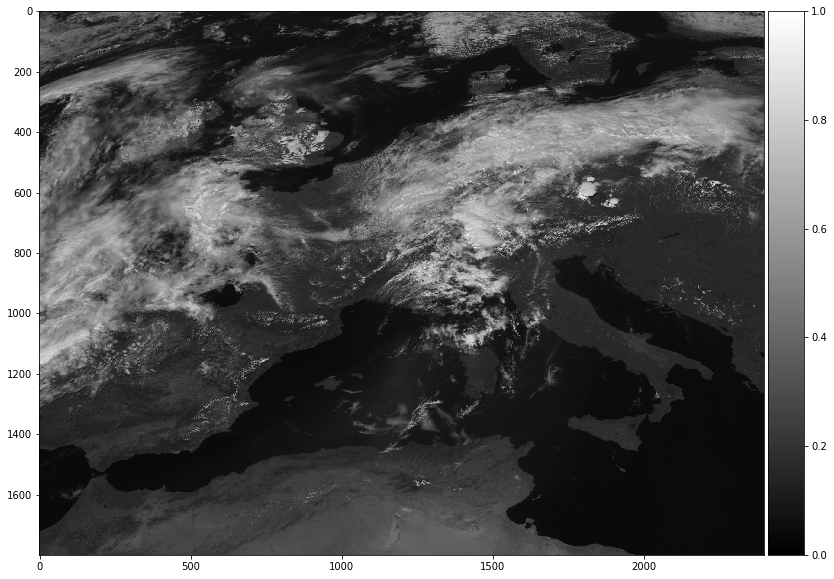

```python
fig,ax = plt.subplots(1,1,figsize=(16,10))
h_plot = ax.imshow(np.clip(sat_data,0,1),vmin=0,vmax=1,cmap='gray')
fc.colourbar(h_plot)
```

Als nächstes versuchen wir die Anzahl der Grauwerte etwas zu reduzieren, um nicht zu große GLCMs zu bekommen.

```python
hrv_norm = np.uint8(np.digitize(sat_data, np.arange(0, np.max(sat_data),1./22))) - 1
```

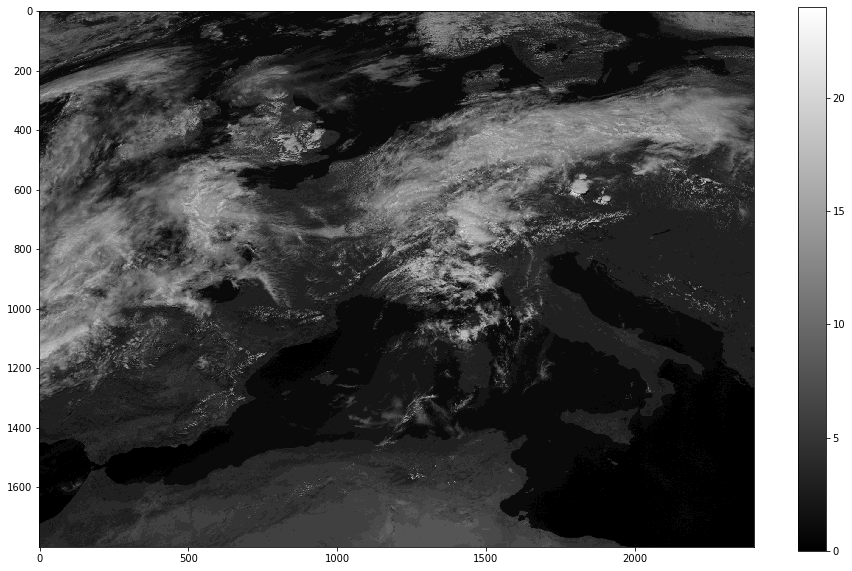

```python
fig,ax = plt.subplots(1,1,figsize=(16,10))
h_plot = ax.imshow(hrv_norm,cmap='gray',vmin=0,vmax=24)
plt.colorbar(h_plot)
```

Ein paar Feinheiten, wie z.B. der Saharastaub gehen verloren, aber im Großen und Ganzen sieht das Bild auch mit der Reduzierung der Graustufen noch brauchbar aus.

Als nächstes durchlaufen wir das ganze Satellitenbild und bestimmen für alle Pixel GLCMs und Texturmaße in einem gegebenen Umkreis.

```python
import time
from IPython.display import clear_output

def update_progress(progress):
    bar_length = 20
    if isinstance(progress, int):
        progress = float(progress)
    if not isinstance(progress, float):
        progress = 0
    if progress < 0:
        progress = 0
    if progress >= 1:
        progress = 1

    block = int(round(bar_length * progress))

    clear_output(wait = True)
    text = "Fortschritt: [{0}] {1:.1f}%".format( "#" * block + "-" * (bar_length - block), progress * 100)
    print(text)

def rolling_window(a, shape):  # rolling window for 2D array
    s = (a.shape[0] - shape[0] + 1,) + (a.shape[1] - shape[1] + 1,) + shape
    strides = a.strides + a.strides
    return np.lib.stride_tricks.as_strided(a, shape=s, strides=strides)

def get_greycoprops4array(array,window_size,n_grey_levels):
    array_shape = array.shape
    out_shape = (2,array_shape[0],array_shape[1])
    out = {'contrast':np.zeros(out_shape),
           'homogeneity':np.zeros(out_shape),
           'ASM':np.zeros(out_shape),
           'correlation':np.zeros(out_shape)}
    half_window = window_size//2

    # create rolling windows of the array
    array_windowed = rolling_window(array,(window_size,window_size))

    # array coordinates
    xx,yy = np.meshgrid(np.arange(0,array.shape[1]),np.arange(0,array.shape[0]))
    xx_windowed = rolling_window(xx,(window_size,window_size))
    yy_windowed = rolling_window(yy,(window_size,window_size))

    # reshape windows
    array_windowed = array_windowed.reshape(array_windowed.shape[0]*array_windowed.shape[1],
                                            window_size,window_size)
    xx_windowed = xx_windowed.reshape(xx_windowed.shape[0]*xx_windowed.shape[1],
                                      window_size,window_size)
    yy_windowed = yy_windowed.reshape(yy_windowed.shape[0]*yy_windowed.shape[1],
                                      window_size,window_size)

    for i, window in enumerate(array_windowed):
        glcm = greycomatrix(window,[1],[0,0.5*np.pi],n_grey_levels+1,symmetric=True,normed=True)

        x = xx_windowed[i][xx_windowed[i].shape[1]//2,xx_windowed[i].shape[0]//2]
        y = yy_windowed[i][yy_windowed[i].shape[1]//2,yy_windowed[i].shape[0]//2]

        for k in out.keys():
            value = greycoprops(glcm,k)

            out[k][0][y,x] = value[0][0]
            out[k][1][y,x] = value[0][1]
        update_progress(i / ((array_shape[0]-window_size) * (array_shape[1]-window_size)))
        i += 1
    return out
```

```python
window_size=7
```

```python
array_windowed = rolling_window(hrv_norm,(window_size,window_size))
```

```python
array_windowed.shape
```

```
(1794, 2394, 7, 7)
```

```python
xx,yy = np.meshgrid(np.arange(0,hrv_norm.shape[1]),np.arange(0,hrv_norm.shape[0]))
xx_windowed = rolling_window(xx,(window_size,window_size))
yy_windowed = rolling_window(yy,(window_size,window_size))
```

```python
array_windowed = array_windowed.reshape(array_windowed.shape[0]*array_windowed.shape[1],
                                            window_size,window_size)
xx_windowed = xx_windowed.reshape(xx_windowed.shape[0]*xx_windowed.shape[1],
                                  window_size,window_size)
yy_windowed = yy_windowed.reshape(yy_windowed.shape[0]*yy_windowed.shape[1],
                                  window_size,window_size)
```

```python
xx_windowed.shape
```

```
(4294836, 7, 7)
```

```python
array_list = array_windowed.tolist()
```

```python
test = (greycomatrix(array_windowed[i],[1],[0,0.5*np.pi],symmetric=True,normed=True) for i in range(array_windowed.shape[0]))
```

```python
array = hrv_norm[540:660,1750:1900]
```

```python
window_size = 5
```

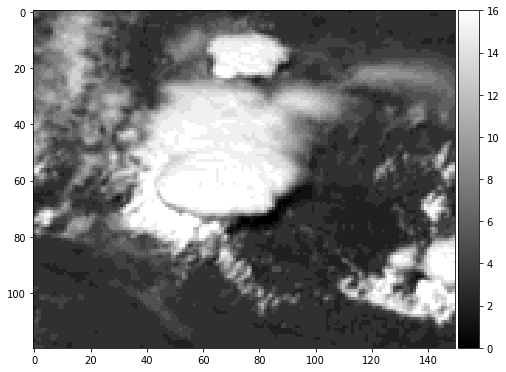

```python
fig,ax = plt.subplots(1,1,figsize=(8,8))
h_plot = ax.imshow(array,vmin=0,vmax=16,cmap='gray')
fc.colourbar(h_plot)
```

```python
texture_measures = get_greycoprops4array(array,7,24)
```

```
Fortschritt: [####################] 100.0%
```

Das funktioniert, ist aber sehr langsam.

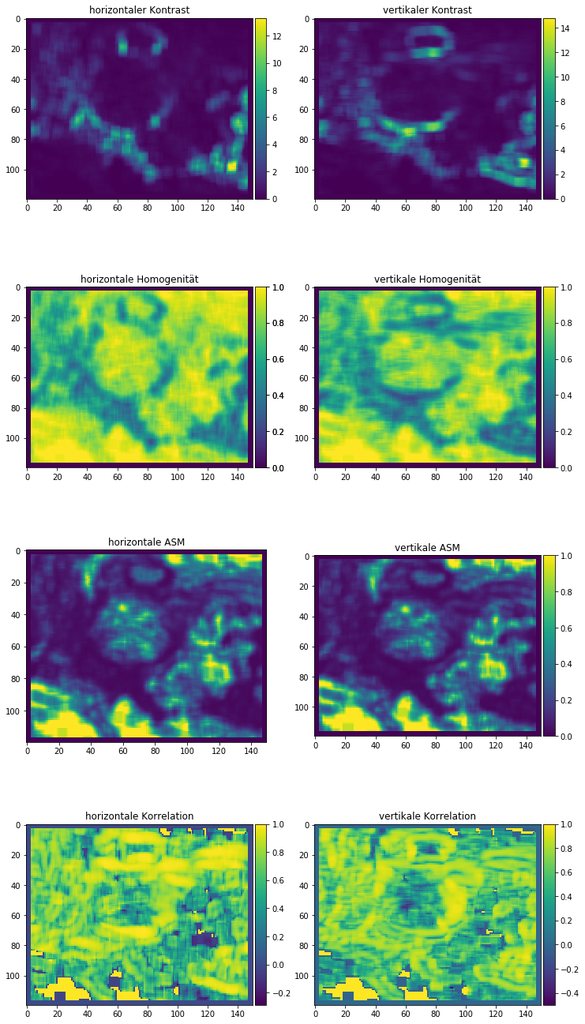

```python
fig,ax = plt.subplots(4,2,figsize=(12,24))
axs = ax.ravel()

kh = axs[0].imshow(texture_measures['contrast'][0])
axs[0].set_title("horizontaler Kontrast")
fc.colourbar(kh)

kv = axs[1].imshow(texture_measures['contrast'][1])
axs[1].set_title("vertikaler Kontrast")
fc.colourbar(kv)

hh = axs[2].imshow(texture_measures['homogeneity'][0])
axs[2].set_title("horizontale Homogenität")
fc.colourbar(hh)

hv = axs[3].imshow(texture_measures['homogeneity'][1])
axs[3].set_title("vertikale Homogenität")
fc.colourbar(hv)

ah = axs[4].imshow(texture_measures['ASM'][0])
axs[4].set_title("horizontale ASM")
fc.colourbar(hh)

av = axs[5].imshow(texture_measures['ASM'][1])
axs[5].set_title("vertikale ASM")
fc.colourbar(av)

ch = axs[6].imshow(texture_measures['correlation'][0])
axs[6].set_title("horizontale Korrelation")
fc.colourbar(ch)

cv = axs[7].imshow(texture_measures['correlation'][1])
axs[7].set_title("vertikale Korrelation")
fc.colourbar(cv)
```

Man kann damit wahrscheinlich Cumulonimbi von der Umgebung trennen:

Allerdings ist die Berechnung sehr langsam. Vielleicht können wir die Berechnung etwas beschleunigen.

```python
def get_greycoprops4array(array,window_size,n_grey_levels):
    from skimage.util import view_as_windows

    array_shape = array.shape
    out_shape = (2,array_shape[0],array_shape[1])
    out = {'contrast':np.zeros(out_shape),
           'homogeneity':np.zeros(out_shape),
           'ASM':np.zeros(out_shape),
           'correlation':np.zeros(out_shape)}
    half_window = window_size//2

    #array_flat = array.flatten()
    #xx,yy = np.meshgrid(np.arange(0,array_shape[0]),np.arange(0,array_shape[1]))
    #for i in np.arange(half_window, len(array_flat)-half_window,1):
    #windows = view_as_windows(array,(window_size,window_size))
    #xx_w = view_as_windows(xx_w,(window_size,window_size))
    #yy_w = view_as_windows(yy_w,(window_size,window_size))
    i = 0
    for x in range(0,array.shape[0] - window_size, 1):
        for y in range(0,array.shape[1] - window_size, 1):
            window = array[x:x + window_size, y:y + window_size]

            glcm = greycomatrix(window,[1],[0,0.5*np.pi],n_grey_levels+1,symmetric=True,normed=True)
            #indexer = np.arange(i-half_window, i+half_window+1)[None, :] + 2*np.arange(i-half_window, i+half_window+1)[:, None]

            for k in out.keys():
                value = greycoprops(glcm,k)

                out[k][0][x+half_window,y+half_window] = value[0][0]
                out[k][1][x+half_window,y+half_window] = value[0][1]
            update_progress(i / ((array_shape[0]-window_size) * (array_shape[1]-window_size)))
            i += 1
    return out
```

```python
from skimage.util import view_as_windows as viewW

def im2col_sliding_strided_v2(A, BSZ, stepsize=1):
    return viewW(A, (BSZ[0],BSZ[1])).reshape(-1,BSZ[0]*BSZ[1]).T[:,::stepsize]
```

```python
from skimage.util import view_as_windows
```

```python
def rolling_window(a, shape):  # rolling window for 2D array
    s = (a.shape[0] - shape[0] + 1,) + (a.shape[1] - shape[1] + 1,) + shape
    strides = a.strides + a.strides
    return np.lib.stride_tricks.as_strided(a, shape=s, strides=strides)

a = np.array([[0,  1,  2,  3,  4,  5],
              [6,  7,  8,  9, 10,  11],
              [12, 13, 14, 15, 7,   8],
              [18, 19, 20, 21, 13, 14],
              [24, 25, 26, 27, 19, 20],
              [30, 31, 32, 33, 34, 35]], dtype=np.int)
b = np.arange(36, dtype=np.float).reshape(6,6)
present = np.array([[7,8],[13,14],[19,20]], dtype=np.int)
absent  = np.array([[7,8],[42,14],[19,20]], dtype=np.int)

found = np.all(np.all(rolling_window(a, present.shape) == present, axis=2), axis=2)
print(np.transpose(found.nonzero()))
found = np.all(np.all(rolling_window(b, present.shape) == present, axis=2), axis=2)
print(np.transpose(found.nonzero()))
found = np.all(np.all(rolling_window(a, absent.shape) == absent, axis=2), axis=2)
print(np.transpose(found.nonzero()))
```

```
[[1 1]
 [2 4]]
[[1 1]]
[]
```

```python
rolling_window(a,(3,3)).shape
```

```
(4, 4, 3, 3)
```

```python
a_w = rolling_window(a,(3,3))
```

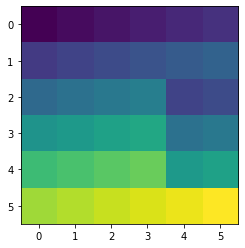

```python
plt.imshow(a,vmin=0,vmax=35)
```

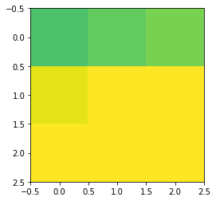

```python
plt.imshow(a_w[3,0,:,:],vmin=0,vmax=25)
```

```python
a_w.reshape(16,3,3)
```

```
array([[[ 0,  1,  2],
        [ 6,  7,  8],
        [12, 13, 14]],

       [[ 1,  2,  3],
        [ 7,  8,  9],
        [13, 14, 15]],

       [[ 2,  3,  4],
        [ 8,  9, 10],
        [14, 15,  7]],

       [[ 3,  4,  5],
        [ 9, 10, 11],
        [15,  7,  8]],

       [[ 6,  7,  8],
        [12, 13, 14],
        [18, 19, 20]],

       [[ 7,  8,  9],
        [13, 14, 15],
        [19, 20, 21]],

       [[ 8,  9, 10],
        [14, 15,  7],
        [20, 21, 13]],

       [[ 9, 10, 11],
        [15,  7,  8],
        [21, 13, 14]],

       [[12, 13, 14],
        [18, 19, 20],
        [24, 25, 26]],

       [[13, 14, 15],
        [19, 20, 21],
        [25, 26, 27]],

```

[output cut: 8 more lines]

```
       [[18, 19, 20],
        [24, 25, 26],
        [30, 31, 32]],

       [[19, 20, 21],
        [25, 26, 27],
        [31, 32, 33]],

       [[20, 21, 13],
        [26, 27, 19],
        [32, 33, 34]],

       [[21, 13, 14],
        [27, 19, 20],
        [33, 34, 35]]])
```

```python
array_w = rolling_window(array,(5,5))
```

```python
array_size = array.shape[0] * array.shape[1]
```

```python
array_w.shape
```

```
(116, 146, 5, 5)
```

```python
array_w = array_w.reshape(int(array_w.shape[0]*array_w.shape[1]), 5, 5)
```

```python
xx,yy = np.meshgrid(np.arange(0,array.shape[0]),np.arange(0,array.shape[1]))
```

```python
xx_w = rolling_window(xx,(5,5))
yy_w = rolling_window(yy,(5,5))
```

```python
xx_w.shape
```

```
(146, 116, 5, 5)
```

```python
xx_w = xx_w.reshape(int(yy_w.shape[0]*xx_w.shape[1]), 5, 5)
yy_w = yy_w.reshape(int(yy_w.shape[0]*yy_w.shape[1]), 5, 5)
```

```python
glcms = []
```

```python
for w in array_w:
    glcm = greycomatrix(w,[1],[0,0.5*np.pi],25,symmetric=True,normed=True)

    glcms.append(glcm)
```

```python
glcm[25]
```

```
---------------------------------------------------------------------------
IndexError                                Traceback (most recent call last)
<ipython-input-268-1146f9c96934> in <module>
----> 1 glcm[25]

IndexError: index 25 is out of bounds for axis 0 with size 25
```

```python
glcm_vec = np.vectorize(greycomatrix)
```

```python
glcm_vec(a_w.reshape(16,3,3),[1],[0,0.5*np.pi],35+1,symmetric=True,normed=True)
```

[output not shown]

```python
144/16
```

```
9.0
```

```python
def get_greycoprops4array2(array,window_size,n_grey_levels):
    from skimage.util import view_as_windows

    array_shape = array.shape
    out_shape = (2,array_shape[0],array_shape[1])
    out = {'contrast':np.zeros(out_shape),
           'homogeneity':np.zeros(out_shape),
           'ASM':np.zeros(out_shape),
           'correlation':np.zeros(out_shape)}

    array_windows = view_as_windows(array,(window_size,window_size))

    i = 0
    for x in np.arange(0,array_windows.shape[0]):
        for y in np.arange(0,array_windows.shape[1]):

            glcm = greycomatrix(array_windows[x,y],[1],[0,0.5*np.pi],n_grey_levels+1,symmetric=True,normed=True)

            for k in out.keys():
                value = greycoprops(glcm,k)

                out[k][0][x,y] = value[0][0]
                out[k][1][x,y] = value[0][1]
            update_progress(i / ((array_shape[0]-window_size) * (array_shape[1]-window_size)))
            i += 1
    return out
```

```python
#test2 = get_greycoprops4array2(hrv_norm[500:600,500:600],7,16)
test = get_greycoprops4array2(array,7,24)
```

```
Fortschritt: [###################-] 95.2%
```

[output not shown]

```python
def get_greycoprops4array_vec(array,window_size,n_grey_levels):
    from skimage.util import view_as_windows

    v_greycomatrix = np.vectorize(greycomatrix)
    v_greycoprops = np.vectorize(greycoprops)

    array_shape = array.shape
    out_shape = (2,array_shape[0],array_shape[1])
    out = {'contrast':np.zeros(out_shape),
           'homogeneity':np.zeros(out_shape),
           'ASM':np.zeros(out_shape),
           'correlation':np.zeros(out_shape)}

    array_windows = view_as_windows(array,(window_size,window_size))

    glcms = v_greycomatrix(array_windows,[1],[0,0.5*np.pi,n_grey_levels+1],symmetric=True,normed=True])

    i = 0
    for x in np.arange(0,array_windows.shape[0]):
        for y in np.arange(0,array_windows.shape[1]):

            glcm = greycomatrix(array_windows[x,y],[1],[0,0.5*np.pi],n_grey_levels+1,symmetric=True,normed=True)

            for k in out.keys():
                value = greycoprops(glcm,k)

                out[k][0][x,y] = value[0][0]
                out[k][1][x,y] = value[0][1]
            update_progress(i / ((array_shape[0]-window_size) * (array_shape[1]-window_size)))
            i += 1
    return out
```

```python
from numba import jit
```

```python
@jit(nopython=True,nogil=True)
def get_greycoprops4array3(array,window_size,n_grey_levels):

    array_shape = array.shape
    out_shape = (2,array_shape[0],array_shape[1])
    out = {'contrast':np.zeros(out_shape),
           'homogeneity':np.zeros(out_shape),
           'ASM':np.zeros(out_shape),
           'correlation':np.zeros(out_shape)}
    half_window = window_size//2

    i = 0
    for x in range(0,array.shape[0] - window_size, 1):
        for y in range(0,array.shape[1] - window_size, 1):
            window = array[x:x + window_size, y:y + window_size]

            glcm = greycomatrix(window,[1],[0,0.5*np.pi],n_grey_levels+1,symmetric=True,normed=True)

            for k in out.keys():
                value = greycoprops(glcm,k)

                out[k][0][x,y] = value[0][0]
                out[k][1][x,y] = value[0][1]
            update_progress(i / ((array_shape[0]-window_size) * (array_shape[1]-window_size)))
            i += 1
    return out
```

```python
test = get_greycoprops4array3(array,5,24)
```

```
Fortschritt: [####################] 100.0%
```

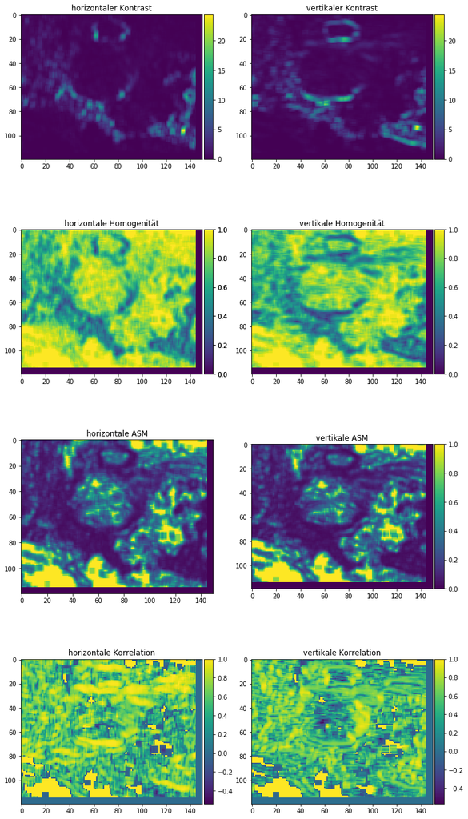

```python
fig,ax = plt.subplots(4,2,figsize=(12,24))
axs = ax.ravel()

kh = axs[0].imshow(test['contrast'][0])
axs[0].set_title("horizontaler Kontrast")
fc.colourbar(kh)

kv = axs[1].imshow(test['contrast'][1])
axs[1].set_title("vertikaler Kontrast")
fc.colourbar(kv)

hh = axs[2].imshow(test['homogeneity'][0])
axs[2].set_title("horizontale Homogenität")
fc.colourbar(hh)

hv = axs[3].imshow(test['homogeneity'][1])
axs[3].set_title("vertikale Homogenität")
fc.colourbar(hv)

ah = axs[4].imshow(test['ASM'][0])
axs[4].set_title("horizontale ASM")
fc.colourbar(hh)

av = axs[5].imshow(test['ASM'][1])
axs[5].set_title("vertikale ASM")
fc.colourbar(av)

ch = axs[6].imshow(test['correlation'][0])
axs[6].set_title("horizontale Korrelation")
fc.colourbar(ch)

cv = axs[7].imshow(test['correlation'][1])
axs[7].set_title("vertikale Korrelation")
fc.colourbar(cv)
```